# 2. Define the Network Architecture

## Define the Convolutional Neural Network

After you've looked at the data you're working with and, in this case, know the shapes of the images and of the keypoints, you are ready to define a convolutional neural network that can *learn* from this data.

In this notebook and in `models.py`, you will:

1. Define a CNN with images as input and keypoints as output
2. Construct the transformed FaceKeypointsDataset, just as before
3. Train the CNN on the training data, tracking loss
4. See how the trained model performs on test data
5. If necessary, modify the CNN structure and model hyperparameters, so that it performs *well* *

* What does *well* mean?

"Well" means that the model's loss decreases during training **and**, when applied to test image data, the model produces keypoints that closely match the true keypoints of each face. And you'll see examples of this later in the notebook.

## CNN Architecture

Recall that CNN's are defined by a few types of layers:

- Convolutional layers
- Maxpooling layers
- Fully-connected layers

You are required to use the above layers and encouraged to add multiple convolutional layers and things like dropout layers that may prevent overfitting. You are also encouraged to look at literature on keypoint detection, such as [this paper](https://arxiv.org/pdf/1710.00977.pdf), to help you determine the structure of your network.

### TODO: Define your model in the provided file `models.py` file

This file is mostly empty but contains the expected name and some TODO's for creating your model.

## PyTorch Neural Nets

To define a neural network in PyTorch, you define the layers of a model in the function `__init__` and define the feedforward behavior of a network that employs those initialized layers in the function `forward`, which takes in an input image tensor, `x`. The structure of this Net class is shown below and left for you to fill in.

Note: During training, PyTorch will be able to perform backpropagation by keeping track of the network's feedforward behavior and using autograd to calculate the update to the weights in the network.

#### Define the Layers in `__init__`

As a reminder, a conv/pool layer may be defined like this (in `__init__`):

```
# 1 input image channel (for grayscale images), 32 output channels/feature maps, 3x3 square convolution kernel
self.conv1 = nn.Conv2d(1, 32, 3)

# maxpool that uses a square window of kernel_size=2, stride=2
self.pool = nn.MaxPool2d(2, 2)
```

#### Refer to Layers in `forward`

Then referred to in the `forward` function like this, in which the conv1 layer has a ReLu activation applied to it before maxpooling is applied:

```
x = self.pool(F.relu(self.conv1(x)))
```

Best practice is to place any layers whose weights will change during the training process in `__init__` and refer to them in the `forward` function; any layers or functions that always behave in the same way, such as a pre-defined activation function, should appear *only* in the `forward` function.

#### Why models.py

You are tasked with defining the network in the `models.py` file so that any models you define can be saved and loaded by name in different notebooks in this project directory. For example, by defining a CNN class called `Net` in `models.py`, you can then create that same architecture in this and other notebooks by simply importing the class and instantiating a model:

```
    from models import Net
    net = Net()
```

```python
# load the data if you need to; if you have already loaded the data, you may comment this cell out
# -- DO NOT CHANGE THIS CELL -- #
!mkdir /data
!wget -P /data/ https://s3.amazonaws.com/video.udacity-data.com/topher/2018/May/5aea1b91_train-test-data/train-test-data.zip
!unzip -n /data/train-test-data.zip -d /data
```

```
mkdir: cannot create directory ‘/data’: File exists
--2020-03-18 17:18:16--  https://s3.amazonaws.com/video.udacity-data.com/topher/2018/May/5aea1b91_train-test-data/train-test-data.zip
Resolving s3.amazonaws.com (s3.amazonaws.com)... 52.217.9.158
Connecting to s3.amazonaws.com (s3.amazonaws.com)|52.217.9.158|:443... connected.
HTTP request sent, awaiting response... 200 OK
Length: 338613624 (323M) [application/zip]
Saving to: ‘/data/train-test-data.zip.1’

train-test-data.zip 100%[===================>] 322.93M  59.6MB/s    in 5.6s

2020-03-18 17:18:21 (58.0 MB/s) - ‘/data/train-test-data.zip.1’ saved [338613624/338613624]

Archive:  /data/train-test-data.zip
```

**Note:** Workspaces automatically close connections after 30 minutes of inactivity (including inactivity while training!). Use the code snippet below to keep your workspace alive during training. (The active_session context manager is imported below.)

```
from workspace_utils import active_session

with active_session():
    train_model(num_epochs)
```

```python
# import the usual resources
import matplotlib.pyplot as plt
import numpy as np

# import utilities to keep workspaces alive during model training
from workspace_utils import active_session

# watch for any changes in model.py, if it changes, re-load it automatically
%load_ext autoreload
%autoreload 2
```

```python
## TODO: Define the Net in models.py

import torch
import torch.nn as nn
import torch.nn.functional as F

## TODO: Once you've define the network, you can instantiate it
# one example conv layer has been provided for you
from models import Net

net = Net()
print(net)
```

```
Net(
  (conv1): Conv2d(1, 16, kernel_size=(5, 5), stride=(1, 1))
  (conv2): Conv2d(16, 32, kernel_size=(5, 5), stride=(1, 1))
  (conv3): Conv2d(32, 64, kernel_size=(3, 3), stride=(1, 1))
  (conv4): Conv2d(64, 128, kernel_size=(3, 3), stride=(1, 1))
  (conv5): Conv2d(128, 256, kernel_size=(3, 3), stride=(1, 1))
  (pool): MaxPool2d(kernel_size=2, stride=2, padding=0, dilation=1, ceil_mode=False)
  (fc1): Linear(in_features=4096, out_features=512, bias=True)
  (fc2): Linear(in_features=512, out_features=136, bias=True)
  (drop1): Dropout(p=0.1)
  (drop2): Dropout(p=0.2)
  (drop3): Dropout(p=0.3)
  (drop4): Dropout(p=0.4)
  (drop5): Dropout(p=0.5)
  (fc1_drop): Dropout(p=0.2)
)
```

## Transform the dataset

To prepare for training, create a transformed dataset of images and keypoints.

### TODO: Define a data transform

In PyTorch, a convolutional neural network expects a torch image of a consistent size as input. For efficient training, and so your model's loss does not blow up during training, it is also suggested that you normalize the input images and keypoints. The necessary transforms have been defined in `data_load.py` and you **do not** need to modify these; take a look at this file (you'll see the same transforms that were defined and applied in Notebook 1).

To define the data transform below, use a [composition](http://pytorch.org/tutorials/beginner/data_loading_tutorial.html#compose-transforms) of:

1. Rescaling and/or cropping the data, such that you are left with a square image (the suggested size is 224x224px)
2. Normalizing the images and keypoints; turning each RGB image into a grayscale image with a color range of [0, 1] and transforming the given keypoints into a range of [-1, 1]
3. Turning these images and keypoints into Tensors

These transformations have been defined in `data_load.py`, but it's up to you to call them and create a `data_transform` below. **This transform will be applied to the training data and, later, the test data**. It will change how you go about displaying these images and keypoints, but these steps are essential for efficient training.

As a note, should you want to perform data augmentation (which is optional in this project), and randomly rotate or shift these images, a square image size will be useful; rotating a 224x224 image by 90 degrees will result in the same shape of output.

```python
from torch.utils.data import Dataset, DataLoader
from torchvision import transforms, utils

# the dataset we created in Notebook 1 is copied in the helper file `data_load.py`
from data_load import FacialKeypointsDataset
# the transforms we defined in Notebook 1 are in the helper file `data_load.py`
from data_load import Rescale, RandomCrop, Normalize, ToTensor


## TODO: define the data_transform using transforms.Compose([all tx's, . , .])
# order matters! i.e. rescaling should come before a smaller crop
data_transform = transforms.Compose([Rescale(250),
                                     RandomCrop(224),
                                     Normalize(),
                                     ToTensor()])

# testing that you've defined a transform
assert(data_transform is not None), 'Define a data_transform'
```

```python
# create the transformed dataset
transformed_dataset = FacialKeypointsDataset(csv_file='/data/training_frames_keypoints.csv',
                                             root_dir='/data/training/',
                                             transform=data_transform)


print('Number of images: ', len(transformed_dataset))

# iterate through the transformed dataset and print some stats about the first few samples
for i in range(4):
    sample = transformed_dataset[i]
    print(i, sample['image'].size(), sample['keypoints'].size())
```

```
Number of images:  3462
0 torch.Size([1, 224, 224]) torch.Size([68, 2])
1 torch.Size([1, 224, 224]) torch.Size([68, 2])
2 torch.Size([1, 224, 224]) torch.Size([68, 2])
3 torch.Size([1, 224, 224]) torch.Size([68, 2])
```

## Batching and loading data

Next, having defined the transformed dataset, we can use PyTorch's DataLoader class to load the training data in batches of whatever size as well as to shuffle the data for training the model. You can read more about the parameters of the DataLoader, in [this documentation](http://pytorch.org/docs/master/data.html).

#### Batch size

Decide on a good batch size for training your model. Try both small and large batch sizes and note how the loss decreases as the model trains. Too large a batch size may cause your model to crash and/or run out of memory while training.

**Note for Windows users**: Please change the `num_workers` to 0 or you may face some issues with your DataLoader failing.

```python
# load training data in batches
batch_size = 10

train_loader = DataLoader(transformed_dataset,
                          batch_size=batch_size,
                          shuffle=True,
                          num_workers=4)
```

## Before training

Take a look at how this model performs before it trains. You should see that the keypoints it predicts start off in one spot and don't match the keypoints on a face at all! It's interesting to visualize this behavior so that you can compare it to the model after training and see how the model has improved.

#### Load in the test dataset

The test dataset is one that this model has *not* seen before, meaning it has not trained with these images. We'll load in this test data and before and after training, see how your model performs on this set!

To visualize this test data, we have to go through some un-transformation steps to turn our images into python images from tensors and to turn our keypoints back into a recognizable range.

```python
# load in the test data, using the dataset class
# AND apply the data_transform you defined above

# create the test dataset
test_dataset = FacialKeypointsDataset(csv_file='/data/test_frames_keypoints.csv',
                                             root_dir='/data/test/',
                                             transform=data_transform)
```

```python
# load test data in batches
batch_size = 10

test_loader = DataLoader(test_dataset,
                          batch_size=batch_size,
                          shuffle=True,
                          num_workers=4)
```

## Apply the model on a test sample

To test the model on a test sample of data, you have to follow these steps:

1. Extract the image and ground truth keypoints from a sample
2. Wrap the image in a Variable, so that the net can process it as input and track how it changes as the image moves through the network.
3. Make sure the image is a FloatTensor, which the model expects.
4. Forward pass the image through the net to get the predicted, output keypoints.

```python
# test the model on a batch of test images

def net_sample_output():

    # iterate through the test dataset
    for i, sample in enumerate(test_loader):

        # get sample data: images and ground truth keypoints
        images = sample['image']
        key_pts = sample['keypoints']

        # convert images to FloatTensors
        images = images.type(torch.FloatTensor)

        # forward pass to get net output
        output_pts = net(images)

        # reshape to batch_size x 68 x 2 pts
        output_pts = output_pts.view(output_pts.size()[0], 68, -1)

        # break after first image is tested
        if i == 0:
            return images, output_pts, key_pts
```

#### Debugging tips

If you get a size or dimension error here, make sure that your network outputs the expected number of keypoints! Or if you get a Tensor type error, look into changing the above code that casts the data into float types: `images = images.type(torch.FloatTensor)`.

```python
# call the above function
# returns: test images, test predicted keypoints, test ground truth keypoints
test_images, test_outputs, gt_pts = net_sample_output()

# print out the dimensions of the data to see if they make sense
print(test_images.data.size())
print(test_outputs.data.size())
print(gt_pts.size())
```

```
torch.Size([10, 1, 224, 224])
torch.Size([10, 68, 2])
torch.Size([10, 68, 2])
```

## Visualize the predicted keypoints

Once we've had the model produce some predicted output keypoints, we can visualize these points in a way that's similar to how we've displayed this data before, only this time, we have to "un-transform" the image/keypoint data to display it.

Note that I've defined a *new* function, `show_all_keypoints` that displays a grayscale image, its predicted keypoints and its ground truth keypoints (if provided).

```python
def show_all_keypoints(image, predicted_key_pts, gt_pts=None):
    """Show image with predicted keypoints"""
    # image is grayscale
    plt.imshow(image, cmap='gray')
    plt.scatter(predicted_key_pts[:, 0], predicted_key_pts[:, 1], s=20, marker='.', c='m')
    # plot ground truth points as green pts
    if gt_pts is not None:
        plt.scatter(gt_pts[:, 0], gt_pts[:, 1], s=20, marker='.', c='g')
```

#### Un-transformation

Next, you'll see a helper function. `visualize_output` that takes in a batch of images, predicted keypoints, and ground truth keypoints and displays a set of those images and their true/predicted keypoints.

This function's main role is to take batches of image and keypoint data (the input and output of your CNN), and transform them into numpy images and un-normalized keypoints (x, y) for normal display. The un-transformation process turns keypoints and images into numpy arrays from Tensors *and* it undoes the keypoint normalization done in the Normalize() transform; it's assumed that you applied these transformations when you loaded your test data.

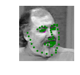

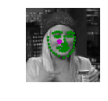

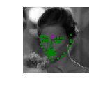

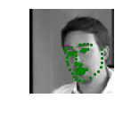

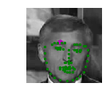

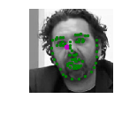

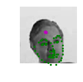

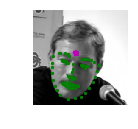

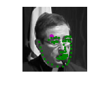

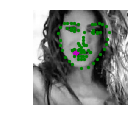

```python
# visualize the output
# by default this shows a batch of 10 images
def visualize_output(test_images, test_outputs, gt_pts=None, batch_size=10):

    for i in range(batch_size):
        plt.figure(figsize=(20,10))
        ax = plt.subplot(1, batch_size, i+1)

        # un-transform the image data
        image = test_images[i].data   # get the image from it's Variable wrapper
        image = image.numpy()   # convert to numpy array from a Tensor
        image = np.transpose(image, (1, 2, 0))   # transpose to go from torch to numpy image

        # un-transform the predicted key_pts data
        predicted_key_pts = test_outputs[i].data
        predicted_key_pts = predicted_key_pts.numpy()
        # undo normalization of keypoints
        predicted_key_pts = predicted_key_pts*50.0+100

        # plot ground truth points for comparison, if they exist
        ground_truth_pts = None
        if gt_pts is not None:
            ground_truth_pts = gt_pts[i]
            ground_truth_pts = ground_truth_pts*50.0+100

        # call show_all_keypoints
        show_all_keypoints(np.squeeze(image), predicted_key_pts, ground_truth_pts)

        plt.axis('off')

    plt.show()

# call it
visualize_output(test_images, test_outputs, gt_pts)
```

## Training

#### Loss function

Training a network to predict keypoints is different than training a network to predict a class; instead of outputting a distribution of classes and using cross entropy loss, you may want to choose a loss function that is suited for regression, which directly compares a predicted value and target value. Read about the various kinds of loss functions (like MSE or L1/SmoothL1 loss) in [this documentation](http://pytorch.org/docs/master/_modules/torch/nn/modules/loss.html).

### TODO: Define the loss and optimization

Next, you'll define how the model will train by deciding on the loss function and optimizer.

```python
## TODO: Define the loss and optimization
import torch.optim as optim

criterion = nn.SmoothL1Loss()

optimizer = optim.Adam(net.parameters(), lr=0.0005)
```

## Training and Initial Observation

Now, you'll train on your batched training data from `train_loader` for a number of epochs.

To quickly observe how your model is training and decide on whether or not you should modify it's structure or hyperparameters, you're encouraged to start off with just one or two epochs at first. As you train, note how your the model's loss behaves over time: does it decrease quickly at first and then slow down? Does it take a while to decrease in the first place? What happens if you change the batch size of your training data or modify your loss function? etc.

Use these initial observations to make changes to your model and decide on the best architecture before you train for many epochs and create a final model.

```python
def train_net(n_epochs):

    # prepare the net for training
    net.train()

    for epoch in range(n_epochs):  # loop over the dataset multiple times

        running_loss = 0.0

        # train on batches of data, assumes you already have train_loader
        for batch_i, data in enumerate(train_loader):
            # get the input images and their corresponding labels
            images = data['image']
            key_pts = data['keypoints']

            # flatten pts
            key_pts = key_pts.view(key_pts.size(0), -1)

            # convert variables to floats for regression loss
            key_pts = key_pts.type(torch.FloatTensor)
            images = images.type(torch.FloatTensor)

            # forward pass to get outputs
            output_pts = net(images)

            # calculate the loss between predicted and target keypoints
            loss = criterion(output_pts, key_pts)

            # zero the parameter (weight) gradients
            optimizer.zero_grad()

            # backward pass to calculate the weight gradients
            loss.backward()

            # update the weights
            optimizer.step()

            # print loss statistics
            running_loss += loss.item()
            if batch_i % 10 == 9:    # print every 10 batches
                print('Epoch: {}, Batch: {}, Avg. Loss: {}'.format(epoch + 1, batch_i+1, running_loss/10))
                running_loss = 0.0

    print('Finished Training')
```

```python
# train your network
n_epochs = 40 # start small, and increase when you've decided on your model structure and hyperparams

# this is a Workspaces-specific context manager to keep the connection
# alive while training your model, not part of pytorch
with active_session():
    train_net(n_epochs)
```

```
Epoch: 1, Batch: 10, Avg. Loss: 0.19864003956317902
Epoch: 1, Batch: 20, Avg. Loss: 0.1135084442794323
Epoch: 1, Batch: 30, Avg. Loss: 0.09946239329874515
Epoch: 1, Batch: 40, Avg. Loss: 0.10231448858976364
Epoch: 1, Batch: 50, Avg. Loss: 0.08562130182981491
Epoch: 1, Batch: 60, Avg. Loss: 0.09107371978461742
Epoch: 1, Batch: 70, Avg. Loss: 0.08991872631013394
Epoch: 1, Batch: 80, Avg. Loss: 0.10088217854499817
Epoch: 1, Batch: 90, Avg. Loss: 0.08999151289463043
Epoch: 1, Batch: 100, Avg. Loss: 0.09388296604156494
Epoch: 1, Batch: 110, Avg. Loss: 0.09228291921317577
Epoch: 1, Batch: 120, Avg. Loss: 0.08504562452435493
Epoch: 1, Batch: 130, Avg. Loss: 0.08725079298019409
Epoch: 1, Batch: 140, Avg. Loss: 0.10556628704071044
Epoch: 1, Batch: 150, Avg. Loss: 0.08501710742712021
Epoch: 1, Batch: 160, Avg. Loss: 0.09785254448652267
Epoch: 1, Batch: 170, Avg. Loss: 0.08881014995276929
Epoch: 1, Batch: 180, Avg. Loss: 0.11129464209079742
Epoch: 1, Batch: 190, Avg. Loss: 0.11189604364335537
Epoch: 1, Batch: 200, Avg. Loss: 0.0972531110048294
Epoch: 1, Batch: 210, Avg. Loss: 0.07746568508446217
Epoch: 1, Batch: 220, Avg. Loss: 0.08094651512801647
Epoch: 1, Batch: 230, Avg. Loss: 0.09487439543008805
Epoch: 1, Batch: 240, Avg. Loss: 0.102142783254385
Epoch: 1, Batch: 250, Avg. Loss: 0.09247836135327817
Epoch: 1, Batch: 260, Avg. Loss: 0.08811167478561402
Epoch: 1, Batch: 270, Avg. Loss: 0.08558909185230731
Epoch: 1, Batch: 280, Avg. Loss: 0.07897022143006324
Epoch: 1, Batch: 290, Avg. Loss: 0.08092938028275967
Epoch: 1, Batch: 300, Avg. Loss: 0.1009971745312214
Epoch: 1, Batch: 310, Avg. Loss: 0.0970723420381546
Epoch: 1, Batch: 320, Avg. Loss: 0.07301280349493026
Epoch: 1, Batch: 330, Avg. Loss: 0.0907377079129219
Epoch: 1, Batch: 340, Avg. Loss: 0.06267236545681953
```

```
Epoch: 2, Batch: 10, Avg. Loss: 0.10096528567373753
Epoch: 2, Batch: 20, Avg. Loss: 0.08346413113176823
Epoch: 2, Batch: 30, Avg. Loss: 0.08319217376410962
Epoch: 2, Batch: 40, Avg. Loss: 0.06889458186924458
Epoch: 2, Batch: 50, Avg. Loss: 0.0872972033917904
Epoch: 2, Batch: 60, Avg. Loss: 0.0723480872809887
Epoch: 2, Batch: 70, Avg. Loss: 0.07785661593079567
Epoch: 2, Batch: 80, Avg. Loss: 0.06962564662098884
Epoch: 2, Batch: 90, Avg. Loss: 0.07337415479123592
Epoch: 2, Batch: 100, Avg. Loss: 0.0801909700036049
Epoch: 2, Batch: 110, Avg. Loss: 0.06981598138809204
Epoch: 2, Batch: 120, Avg. Loss: 0.0697016853839159
Epoch: 2, Batch: 130, Avg. Loss: 0.07009253352880478
Epoch: 2, Batch: 140, Avg. Loss: 0.10679499618709087
Epoch: 2, Batch: 150, Avg. Loss: 0.07225692234933376
Epoch: 2, Batch: 160, Avg. Loss: 0.0817520909011364
Epoch: 2, Batch: 170, Avg. Loss: 0.08400565348565578
Epoch: 2, Batch: 180, Avg. Loss: 0.0794090237468481
Epoch: 2, Batch: 190, Avg. Loss: 0.06015328913927078
Epoch: 2, Batch: 200, Avg. Loss: 0.080130310729146
Epoch: 2, Batch: 210, Avg. Loss: 0.06896807514131069
Epoch: 2, Batch: 220, Avg. Loss: 0.06664210148155689
Epoch: 2, Batch: 230, Avg. Loss: 0.07167039848864079
Epoch: 2, Batch: 240, Avg. Loss: 0.059066937677562235
Epoch: 2, Batch: 250, Avg. Loss: 0.0877003788948059
Epoch: 2, Batch: 260, Avg. Loss: 0.07917285263538361
Epoch: 2, Batch: 270, Avg. Loss: 0.07645286843180657
Epoch: 2, Batch: 280, Avg. Loss: 0.0706466268748045
Epoch: 2, Batch: 290, Avg. Loss: 0.07580646313726902
Epoch: 2, Batch: 300, Avg. Loss: 0.07123819403350354
Epoch: 2, Batch: 310, Avg. Loss: 0.061871583387255666
Epoch: 2, Batch: 320, Avg. Loss: 0.06616421844810247
Epoch: 2, Batch: 330, Avg. Loss: 0.0599235188215971
Epoch: 2, Batch: 340, Avg. Loss: 0.04782815258949995
```

```
Epoch: 3, Batch: 10, Avg. Loss: 0.09694478064775466
Epoch: 3, Batch: 20, Avg. Loss: 0.08161005899310111
Epoch: 3, Batch: 30, Avg. Loss: 0.07418399788439274
Epoch: 3, Batch: 40, Avg. Loss: 0.06209130771458149
Epoch: 3, Batch: 50, Avg. Loss: 0.07934718616306782
Epoch: 3, Batch: 60, Avg. Loss: 0.0830511435866356
Epoch: 3, Batch: 70, Avg. Loss: 0.054561424627900125
Epoch: 3, Batch: 80, Avg. Loss: 0.05434709805995226
Epoch: 3, Batch: 90, Avg. Loss: 0.047340072505176065
Epoch: 3, Batch: 100, Avg. Loss: 0.06602614596486092
Epoch: 3, Batch: 110, Avg. Loss: 0.04492420144379139
Epoch: 3, Batch: 120, Avg. Loss: 0.06663061790168286
Epoch: 3, Batch: 130, Avg. Loss: 0.05319836512207985
Epoch: 3, Batch: 140, Avg. Loss: 0.05620845593512058
Epoch: 3, Batch: 150, Avg. Loss: 0.05326540470123291
Epoch: 3, Batch: 160, Avg. Loss: 0.04367931578308344
Epoch: 3, Batch: 170, Avg. Loss: 0.050202039815485475
Epoch: 3, Batch: 180, Avg. Loss: 0.03735509794205427
Epoch: 3, Batch: 190, Avg. Loss: 0.04668659996241331
Epoch: 3, Batch: 200, Avg. Loss: 0.04823512658476829
Epoch: 3, Batch: 210, Avg. Loss: 0.04408728461712599
Epoch: 3, Batch: 220, Avg. Loss: 0.04792021792382002
Epoch: 3, Batch: 230, Avg. Loss: 0.05832410622388125
Epoch: 3, Batch: 240, Avg. Loss: 0.05011962242424488
Epoch: 3, Batch: 250, Avg. Loss: 0.04812272675335407
Epoch: 3, Batch: 260, Avg. Loss: 0.04214001726359129
Epoch: 3, Batch: 270, Avg. Loss: 0.05740462336689234
Epoch: 3, Batch: 280, Avg. Loss: 0.04357062093913555
Epoch: 3, Batch: 290, Avg. Loss: 0.05127212014049291
Epoch: 3, Batch: 300, Avg. Loss: 0.036529181711375716
Epoch: 3, Batch: 310, Avg. Loss: 0.0318000290542841
Epoch: 3, Batch: 320, Avg. Loss: 0.03462587799876928
Epoch: 3, Batch: 330, Avg. Loss: 0.043818942829966546
Epoch: 3, Batch: 340, Avg. Loss: 0.0343068509362638
```

```
Epoch: 4, Batch: 10, Avg. Loss: 0.03716177027672529
Epoch: 4, Batch: 20, Avg. Loss: 0.037429499067366125
Epoch: 4, Batch: 30, Avg. Loss: 0.05189743302762508
Epoch: 4, Batch: 40, Avg. Loss: 0.0590746970847249
Epoch: 4, Batch: 50, Avg. Loss: 0.031775229051709174
Epoch: 4, Batch: 60, Avg. Loss: 0.040066858753561974
Epoch: 4, Batch: 70, Avg. Loss: 0.03806784078478813
Epoch: 4, Batch: 80, Avg. Loss: 0.03598360791802406
Epoch: 4, Batch: 90, Avg. Loss: 0.03694150922819972
Epoch: 4, Batch: 100, Avg. Loss: 0.026707475632429124
Epoch: 4, Batch: 110, Avg. Loss: 0.05058106891810894
Epoch: 4, Batch: 120, Avg. Loss: 0.028999120369553565
Epoch: 4, Batch: 130, Avg. Loss: 0.03479161635041237
Epoch: 4, Batch: 140, Avg. Loss: 0.03659226940944791
Epoch: 4, Batch: 150, Avg. Loss: 0.029546496272087098
Epoch: 4, Batch: 160, Avg. Loss: 0.04215698093175888
Epoch: 4, Batch: 170, Avg. Loss: 0.03194694556295872
Epoch: 4, Batch: 180, Avg. Loss: 0.05620829742401838
Epoch: 4, Batch: 190, Avg. Loss: 0.027078527957201004
Epoch: 4, Batch: 200, Avg. Loss: 0.037663030438125134
Epoch: 4, Batch: 210, Avg. Loss: 0.031110934726893903
Epoch: 4, Batch: 220, Avg. Loss: 0.02538899313658476
Epoch: 4, Batch: 230, Avg. Loss: 0.036447014473378656
Epoch: 4, Batch: 240, Avg. Loss: 0.03927652239799499
Epoch: 4, Batch: 250, Avg. Loss: 0.04806308560073376
Epoch: 4, Batch: 260, Avg. Loss: 0.028045745752751827
Epoch: 4, Batch: 270, Avg. Loss: 0.04933157842606306
Epoch: 4, Batch: 280, Avg. Loss: 0.03335840031504631
Epoch: 4, Batch: 290, Avg. Loss: 0.038771156873553994
Epoch: 4, Batch: 300, Avg. Loss: 0.032504803780466315
Epoch: 4, Batch: 310, Avg. Loss: 0.02594047961756587
Epoch: 4, Batch: 320, Avg. Loss: 0.03462765449658036
Epoch: 4, Batch: 330, Avg. Loss: 0.0354965103790164
Epoch: 4, Batch: 340, Avg. Loss: 0.04596895277500153
```

```
Epoch: 5, Batch: 10, Avg. Loss: 0.035467739775776864
Epoch: 5, Batch: 20, Avg. Loss: 0.03818310759961605
Epoch: 5, Batch: 30, Avg. Loss: 0.025379627570509912
Epoch: 5, Batch: 40, Avg. Loss: 0.02234667055308819
Epoch: 5, Batch: 50, Avg. Loss: 0.03192519638687372
Epoch: 5, Batch: 60, Avg. Loss: 0.027800391521304847
Epoch: 5, Batch: 70, Avg. Loss: 0.029994613397866486
Epoch: 5, Batch: 80, Avg. Loss: 0.021749854274094104
Epoch: 5, Batch: 90, Avg. Loss: 0.028902255557477476
Epoch: 5, Batch: 100, Avg. Loss: 0.035182314552366735
Epoch: 5, Batch: 110, Avg. Loss: 0.018127431999891995
Epoch: 5, Batch: 120, Avg. Loss: 0.037507652025669816
Epoch: 5, Batch: 130, Avg. Loss: 0.019369746651500465
Epoch: 5, Batch: 140, Avg. Loss: 0.02577084265649319
Epoch: 5, Batch: 150, Avg. Loss: 0.02581256628036499
Epoch: 5, Batch: 160, Avg. Loss: 0.036722456011921166
Epoch: 5, Batch: 170, Avg. Loss: 0.03322867695242167
Epoch: 5, Batch: 180, Avg. Loss: 0.034694145899266005
Epoch: 5, Batch: 190, Avg. Loss: 0.02726002186536789
Epoch: 5, Batch: 200, Avg. Loss: 0.030212637037038803
Epoch: 5, Batch: 210, Avg. Loss: 0.019174196384847166
Epoch: 5, Batch: 220, Avg. Loss: 0.026243106368929146
Epoch: 5, Batch: 230, Avg. Loss: 0.021595734730362894
Epoch: 5, Batch: 240, Avg. Loss: 0.021637689042836427
Epoch: 5, Batch: 250, Avg. Loss: 0.0354271138086915
Epoch: 5, Batch: 260, Avg. Loss: 0.032200618833303454
Epoch: 5, Batch: 270, Avg. Loss: 0.02085770759731531
Epoch: 5, Batch: 280, Avg. Loss: 0.03422746360301972
Epoch: 5, Batch: 290, Avg. Loss: 0.034425722993910314
Epoch: 5, Batch: 300, Avg. Loss: 0.02267434010282159
Epoch: 5, Batch: 310, Avg. Loss: 0.016386999003589153
Epoch: 5, Batch: 320, Avg. Loss: 0.020492898114025593
Epoch: 5, Batch: 330, Avg. Loss: 0.019064203929156066
Epoch: 5, Batch: 340, Avg. Loss: 0.03398263566195965
```

```
Epoch: 6, Batch: 10, Avg. Loss: 0.03419184321537614
Epoch: 6, Batch: 20, Avg. Loss: 0.020300965290516615
Epoch: 6, Batch: 30, Avg. Loss: 0.019557857513427736
Epoch: 6, Batch: 40, Avg. Loss: 0.018784993235021828
Epoch: 6, Batch: 50, Avg. Loss: 0.021425815671682356
Epoch: 6, Batch: 60, Avg. Loss: 0.024473589938133956
Epoch: 6, Batch: 70, Avg. Loss: 0.022089967411011456
Epoch: 6, Batch: 80, Avg. Loss: 0.023977429419755936
Epoch: 6, Batch: 90, Avg. Loss: 0.0250898951664567
Epoch: 6, Batch: 100, Avg. Loss: 0.01995557975023985
Epoch: 6, Batch: 110, Avg. Loss: 0.01816026261076331
Epoch: 6, Batch: 120, Avg. Loss: 0.017451212741434574
Epoch: 6, Batch: 130, Avg. Loss: 0.03144396552816033
Epoch: 6, Batch: 140, Avg. Loss: 0.02091898173093796
Epoch: 6, Batch: 150, Avg. Loss: 0.02528377315029502
Epoch: 6, Batch: 160, Avg. Loss: 0.022155517153441905
Epoch: 6, Batch: 170, Avg. Loss: 0.01871667611412704
Epoch: 6, Batch: 180, Avg. Loss: 0.023251022025942803
Epoch: 6, Batch: 190, Avg. Loss: 0.01571262963116169
Epoch: 6, Batch: 200, Avg. Loss: 0.018826600350439548
Epoch: 6, Batch: 210, Avg. Loss: 0.01797645017504692
Epoch: 6, Batch: 220, Avg. Loss: 0.033120366744697094
Epoch: 6, Batch: 230, Avg. Loss: 0.023420364875346423
Epoch: 6, Batch: 240, Avg. Loss: 0.022115296311676504
Epoch: 6, Batch: 250, Avg. Loss: 0.022822129912674426
Epoch: 6, Batch: 260, Avg. Loss: 0.02197522232308984
Epoch: 6, Batch: 270, Avg. Loss: 0.01873921984806657
Epoch: 6, Batch: 280, Avg. Loss: 0.021538190171122552
Epoch: 6, Batch: 290, Avg. Loss: 0.03797616800293326
Epoch: 6, Batch: 300, Avg. Loss: 0.018153118994086982
Epoch: 6, Batch: 310, Avg. Loss: 0.023761160857975482
Epoch: 6, Batch: 320, Avg. Loss: 0.03939048824831844
Epoch: 6, Batch: 330, Avg. Loss: 0.024048052821308376
Epoch: 6, Batch: 340, Avg. Loss: 0.017301005264744162
```

```
Epoch: 7, Batch: 10, Avg. Loss: 0.02081499546766281
Epoch: 7, Batch: 20, Avg. Loss: 0.020838017016649245
Epoch: 7, Batch: 30, Avg. Loss: 0.018184229079633952
Epoch: 7, Batch: 40, Avg. Loss: 0.014124225173145533
Epoch: 7, Batch: 50, Avg. Loss: 0.01580313965678215
Epoch: 7, Batch: 60, Avg. Loss: 0.017342926235869527
Epoch: 7, Batch: 70, Avg. Loss: 0.02329130917787552
Epoch: 7, Batch: 80, Avg. Loss: 0.03019442465156317
Epoch: 7, Batch: 90, Avg. Loss: 0.017997401859611274
Epoch: 7, Batch: 100, Avg. Loss: 0.02543245451524854
Epoch: 7, Batch: 110, Avg. Loss: 0.04394677886739373
Epoch: 7, Batch: 120, Avg. Loss: 0.022486964892596006
Epoch: 7, Batch: 130, Avg. Loss: 0.023181470576673746
Epoch: 7, Batch: 140, Avg. Loss: 0.02205184530466795
Epoch: 7, Batch: 150, Avg. Loss: 0.01513359835371375
Epoch: 7, Batch: 160, Avg. Loss: 0.014357277471572161
Epoch: 7, Batch: 170, Avg. Loss: 0.03330944655463099
Epoch: 7, Batch: 180, Avg. Loss: 0.02219714680686593
Epoch: 7, Batch: 190, Avg. Loss: 0.024607927724719047
Epoch: 7, Batch: 200, Avg. Loss: 0.017204375844448803
Epoch: 7, Batch: 210, Avg. Loss: 0.018956099264323713
Epoch: 7, Batch: 220, Avg. Loss: 0.03406806560233235
Epoch: 7, Batch: 230, Avg. Loss: 0.018499328289180994
Epoch: 7, Batch: 240, Avg. Loss: 0.022630786616355182
Epoch: 7, Batch: 250, Avg. Loss: 0.01565858842805028
Epoch: 7, Batch: 260, Avg. Loss: 0.017708133906126022
Epoch: 7, Batch: 270, Avg. Loss: 0.015249987598508596
Epoch: 7, Batch: 280, Avg. Loss: 0.01668805629014969
Epoch: 7, Batch: 290, Avg. Loss: 0.05142741911113262
Epoch: 7, Batch: 300, Avg. Loss: 0.016630985867232086
Epoch: 7, Batch: 310, Avg. Loss: 0.015934041794389488
Epoch: 7, Batch: 320, Avg. Loss: 0.015082230977714061
Epoch: 7, Batch: 330, Avg. Loss: 0.018866732250899076
Epoch: 7, Batch: 340, Avg. Loss: 0.02332464512437582
```

```
Epoch: 8, Batch: 10, Avg. Loss: 0.017927021346986295
Epoch: 8, Batch: 20, Avg. Loss: 0.034015066688880324
Epoch: 8, Batch: 30, Avg. Loss: 0.019422418903559446
Epoch: 8, Batch: 40, Avg. Loss: 0.02583447126671672
Epoch: 8, Batch: 50, Avg. Loss: 0.018325049057602884
Epoch: 8, Batch: 60, Avg. Loss: 0.016027916828170417
Epoch: 8, Batch: 70, Avg. Loss: 0.017488450976088643
Epoch: 8, Batch: 80, Avg. Loss: 0.023119566030800343
Epoch: 8, Batch: 90, Avg. Loss: 0.014743588212877513
Epoch: 8, Batch: 100, Avg. Loss: 0.01409148909151554
Epoch: 8, Batch: 110, Avg. Loss: 0.022319973539561035
Epoch: 8, Batch: 120, Avg. Loss: 0.01375048765912652
Epoch: 8, Batch: 130, Avg. Loss: 0.014539660280570387
Epoch: 8, Batch: 140, Avg. Loss: 0.02459011161699891
Epoch: 8, Batch: 150, Avg. Loss: 0.015178705379366875
Epoch: 8, Batch: 160, Avg. Loss: 0.01827976470813155
Epoch: 8, Batch: 170, Avg. Loss: 0.019660330656915904
Epoch: 8, Batch: 180, Avg. Loss: 0.014157656440511346
Epoch: 8, Batch: 190, Avg. Loss: 0.012924519460648298
Epoch: 8, Batch: 200, Avg. Loss: 0.01487718028947711
Epoch: 8, Batch: 210, Avg. Loss: 0.014042826648801566
Epoch: 8, Batch: 220, Avg. Loss: 0.020030301297083497
Epoch: 8, Batch: 230, Avg. Loss: 0.015250999433919787
Epoch: 8, Batch: 240, Avg. Loss: 0.01679081879556179
Epoch: 8, Batch: 250, Avg. Loss: 0.0231274769641459
Epoch: 8, Batch: 260, Avg. Loss: 0.01411631442606449
Epoch: 8, Batch: 270, Avg. Loss: 0.035516385175287726
Epoch: 8, Batch: 280, Avg. Loss: 0.02701374189928174
Epoch: 8, Batch: 290, Avg. Loss: 0.016375953517854213
Epoch: 8, Batch: 300, Avg. Loss: 0.020374397188425063
Epoch: 8, Batch: 310, Avg. Loss: 0.02980661727488041
Epoch: 8, Batch: 320, Avg. Loss: 0.021099817473441362
Epoch: 8, Batch: 330, Avg. Loss: 0.015165731776505709
Epoch: 8, Batch: 340, Avg. Loss: 0.014049926213920117
```

```
Epoch: 9, Batch: 10, Avg. Loss: 0.027922024577856065
Epoch: 9, Batch: 20, Avg. Loss: 0.021217651758342983
Epoch: 9, Batch: 30, Avg. Loss: 0.010433373181149364
Epoch: 9, Batch: 40, Avg. Loss: 0.013800596119835973
Epoch: 9, Batch: 50, Avg. Loss: 0.013193979579955339
Epoch: 9, Batch: 60, Avg. Loss: 0.016479914542287588
Epoch: 9, Batch: 70, Avg. Loss: 0.012090360093861819
Epoch: 9, Batch: 80, Avg. Loss: 0.029379150411114097
Epoch: 9, Batch: 90, Avg. Loss: 0.012080898229032754
Epoch: 9, Batch: 100, Avg. Loss: 0.014732307940721511
Epoch: 9, Batch: 110, Avg. Loss: 0.0429253363981843
Epoch: 9, Batch: 120, Avg. Loss: 0.012068837834522127
Epoch: 9, Batch: 130, Avg. Loss: 0.012061369698494672
Epoch: 9, Batch: 140, Avg. Loss: 0.015842443984001874
Epoch: 9, Batch: 150, Avg. Loss: 0.014004776207730173
Epoch: 9, Batch: 160, Avg. Loss: 0.012256027013063431
Epoch: 9, Batch: 170, Avg. Loss: 0.01311827227473259
Epoch: 9, Batch: 180, Avg. Loss: 0.01138020814396441
Epoch: 9, Batch: 190, Avg. Loss: 0.01683062994852662
Epoch: 9, Batch: 200, Avg. Loss: 0.011174512514844536
Epoch: 9, Batch: 210, Avg. Loss: 0.011564468685537576
Epoch: 9, Batch: 220, Avg. Loss: 0.03860856294631958
Epoch: 9, Batch: 230, Avg. Loss: 0.011939475312829018
Epoch: 9, Batch: 240, Avg. Loss: 0.020777317136526106
Epoch: 9, Batch: 250, Avg. Loss: 0.013815418910235166
Epoch: 9, Batch: 260, Avg. Loss: 0.01281542694196105
Epoch: 9, Batch: 270, Avg. Loss: 0.01173658836632967
Epoch: 9, Batch: 280, Avg. Loss: 0.017974093928933142
Epoch: 9, Batch: 290, Avg. Loss: 0.014582715695723891
Epoch: 9, Batch: 300, Avg. Loss: 0.010828077886253595
Epoch: 9, Batch: 310, Avg. Loss: 0.012954371236264705
Epoch: 9, Batch: 320, Avg. Loss: 0.020114175137132408
Epoch: 9, Batch: 330, Avg. Loss: 0.012175302021205425
Epoch: 9, Batch: 340, Avg. Loss: 0.0189984280616045
```

```
Epoch: 10, Batch: 10, Avg. Loss: 0.025421955436468125
Epoch: 10, Batch: 20, Avg. Loss: 0.014322292804718018
Epoch: 10, Batch: 30, Avg. Loss: 0.020657151844352482
Epoch: 10, Batch: 40, Avg. Loss: 0.013489789050072431
Epoch: 10, Batch: 50, Avg. Loss: 0.01581624075770378
Epoch: 10, Batch: 60, Avg. Loss: 0.011523589957505465
Epoch: 10, Batch: 70, Avg. Loss: 0.013547433447092772
Epoch: 10, Batch: 80, Avg. Loss: 0.01851238599047065
Epoch: 10, Batch: 90, Avg. Loss: 0.012230260111391545
Epoch: 10, Batch: 100, Avg. Loss: 0.01322976453229785
Epoch: 10, Batch: 110, Avg. Loss: 0.01773160547018051
Epoch: 10, Batch: 120, Avg. Loss: 0.020931133534759283
Epoch: 10, Batch: 130, Avg. Loss: 0.0169817712623626
Epoch: 10, Batch: 140, Avg. Loss: 0.03963737040758133
Epoch: 10, Batch: 150, Avg. Loss: 0.010222947830334306
Epoch: 10, Batch: 160, Avg. Loss: 0.009474878245964647
Epoch: 10, Batch: 170, Avg. Loss: 0.023507796041667462
Epoch: 10, Batch: 180, Avg. Loss: 0.013732183817774057
Epoch: 10, Batch: 190, Avg. Loss: 0.010274655418470502
Epoch: 10, Batch: 200, Avg. Loss: 0.04438587026670575
Epoch: 10, Batch: 210, Avg. Loss: 0.014562820643186569
Epoch: 10, Batch: 220, Avg. Loss: 0.00968549600802362
Epoch: 10, Batch: 230, Avg. Loss: 0.01580126816406846
Epoch: 10, Batch: 240, Avg. Loss: 0.020765509735792876
Epoch: 10, Batch: 250, Avg. Loss: 0.01974152820184827
Epoch: 10, Batch: 260, Avg. Loss: 0.0161624685395509
Epoch: 10, Batch: 270, Avg. Loss: 0.012693946156650782
Epoch: 10, Batch: 280, Avg. Loss: 0.011549342656508088
Epoch: 10, Batch: 290, Avg. Loss: 0.026579501014202832
Epoch: 10, Batch: 300, Avg. Loss: 0.013858169596642256
Epoch: 10, Batch: 310, Avg. Loss: 0.022368243942037225
Epoch: 10, Batch: 320, Avg. Loss: 0.013957125367596745
Epoch: 10, Batch: 330, Avg. Loss: 0.01189793860539794
Epoch: 10, Batch: 340, Avg. Loss: 0.018037960678339005
```

```
Epoch: 11, Batch: 10, Avg. Loss: 0.01678187311626971
Epoch: 11, Batch: 20, Avg. Loss: 0.013883229112252593
Epoch: 11, Batch: 30, Avg. Loss: 0.019854546478018164
Epoch: 11, Batch: 40, Avg. Loss: 0.013168496359139682
Epoch: 11, Batch: 50, Avg. Loss: 0.009325557155534625
Epoch: 11, Batch: 60, Avg. Loss: 0.019234866462647916
Epoch: 11, Batch: 70, Avg. Loss: 0.02195731531828642
Epoch: 11, Batch: 80, Avg. Loss: 0.021965313842520116
Epoch: 11, Batch: 90, Avg. Loss: 0.01332979234866798
Epoch: 11, Batch: 100, Avg. Loss: 0.012560704257339239
Epoch: 11, Batch: 110, Avg. Loss: 0.01246381183154881
Epoch: 11, Batch: 120, Avg. Loss: 0.01580803170800209
Epoch: 11, Batch: 130, Avg. Loss: 0.018525171838700772
Epoch: 11, Batch: 140, Avg. Loss: 0.012505253544077277
Epoch: 11, Batch: 150, Avg. Loss: 0.014610165171325207
Epoch: 11, Batch: 160, Avg. Loss: 0.012970943935215473
Epoch: 11, Batch: 170, Avg. Loss: 0.027720310911536216
Epoch: 11, Batch: 180, Avg. Loss: 0.013886668812483549
Epoch: 11, Batch: 190, Avg. Loss: 0.029241042397916316
Epoch: 11, Batch: 200, Avg. Loss: 0.011838859785348177
Epoch: 11, Batch: 210, Avg. Loss: 0.012678163638338447
Epoch: 11, Batch: 220, Avg. Loss: 0.014374487660825252
Epoch: 11, Batch: 230, Avg. Loss: 0.020265748677775263
Epoch: 11, Batch: 240, Avg. Loss: 0.03382454756647348
Epoch: 11, Batch: 250, Avg. Loss: 0.01342356763780117
Epoch: 11, Batch: 260, Avg. Loss: 0.011722061177715659
Epoch: 11, Batch: 270, Avg. Loss: 0.019640571577474474
Epoch: 11, Batch: 280, Avg. Loss: 0.026741344761103392
Epoch: 11, Batch: 290, Avg. Loss: 0.02271638475358486
Epoch: 11, Batch: 300, Avg. Loss: 0.020218613976612686
Epoch: 11, Batch: 310, Avg. Loss: 0.016929470095783473
Epoch: 11, Batch: 320, Avg. Loss: 0.017355761537328363
Epoch: 11, Batch: 330, Avg. Loss: 0.011380907753482461
Epoch: 11, Batch: 340, Avg. Loss: 0.01029096865095198
```

```
Epoch: 12, Batch: 10, Avg. Loss: 0.030743667203933
Epoch: 12, Batch: 20, Avg. Loss: 0.013199529843404889
Epoch: 12, Batch: 30, Avg. Loss: 0.025711290119215847
Epoch: 12, Batch: 40, Avg. Loss: 0.013264697650447488
Epoch: 12, Batch: 50, Avg. Loss: 0.010558532550930977
Epoch: 12, Batch: 60, Avg. Loss: 0.015399073343724012
Epoch: 12, Batch: 70, Avg. Loss: 0.036629862152040005
Epoch: 12, Batch: 80, Avg. Loss: 0.011925952462479471
Epoch: 12, Batch: 90, Avg. Loss: 0.01220460031181574
Epoch: 12, Batch: 100, Avg. Loss: 0.01014888696372509
Epoch: 12, Batch: 110, Avg. Loss: 0.012300477921962738
Epoch: 12, Batch: 120, Avg. Loss: 0.00883265295997262
Epoch: 12, Batch: 130, Avg. Loss: 0.012433550134301186
Epoch: 12, Batch: 140, Avg. Loss: 0.011894254805520177
Epoch: 12, Batch: 150, Avg. Loss: 0.01089643226005137
Epoch: 12, Batch: 160, Avg. Loss: 0.00885123568587005
Epoch: 12, Batch: 170, Avg. Loss: 0.011628028471022844
Epoch: 12, Batch: 180, Avg. Loss: 0.0102867241948843
Epoch: 12, Batch: 190, Avg. Loss: 0.014603685913607478
Epoch: 12, Batch: 200, Avg. Loss: 0.009218869591131806
Epoch: 12, Batch: 210, Avg. Loss: 0.022337270714342595
Epoch: 12, Batch: 220, Avg. Loss: 0.010530748264864087
Epoch: 12, Batch: 230, Avg. Loss: 0.007688163034617901
Epoch: 12, Batch: 240, Avg. Loss: 0.018142877612262964
Epoch: 12, Batch: 250, Avg. Loss: 0.012846646923571825
Epoch: 12, Batch: 260, Avg. Loss: 0.010774828353896737
Epoch: 12, Batch: 270, Avg. Loss: 0.008027232903987169
Epoch: 12, Batch: 280, Avg. Loss: 0.010384834604337811
Epoch: 12, Batch: 290, Avg. Loss: 0.009514321340247989
Epoch: 12, Batch: 300, Avg. Loss: 0.012160244630649686
Epoch: 12, Batch: 310, Avg. Loss: 0.01855265935882926
Epoch: 12, Batch: 320, Avg. Loss: 0.015895489929243924
Epoch: 12, Batch: 330, Avg. Loss: 0.009916915092617273
Epoch: 12, Batch: 340, Avg. Loss: 0.026229951670393346
```

```
Epoch: 13, Batch: 10, Avg. Loss: 0.01123840413056314
Epoch: 13, Batch: 20, Avg. Loss: 0.010573513992130756
Epoch: 13, Batch: 30, Avg. Loss: 0.009281901037320494
Epoch: 13, Batch: 40, Avg. Loss: 0.009107277961447835
Epoch: 13, Batch: 50, Avg. Loss: 0.007944576954469085
Epoch: 13, Batch: 60, Avg. Loss: 0.020370603539049625
Epoch: 13, Batch: 70, Avg. Loss: 0.00934558678418398
Epoch: 13, Batch: 80, Avg. Loss: 0.03248569937422872
Epoch: 13, Batch: 90, Avg. Loss: 0.03025009362027049
Epoch: 13, Batch: 100, Avg. Loss: 0.012988038966432214
Epoch: 13, Batch: 110, Avg. Loss: 0.011614973843097686
Epoch: 13, Batch: 120, Avg. Loss: 0.010708481539040804
Epoch: 13, Batch: 130, Avg. Loss: 0.029068237729370595
Epoch: 13, Batch: 140, Avg. Loss: 0.008893859758973121
Epoch: 13, Batch: 150, Avg. Loss: 0.01812463947571814
Epoch: 13, Batch: 160, Avg. Loss: 0.012696255557239055
Epoch: 13, Batch: 170, Avg. Loss: 0.010626870673149824
Epoch: 13, Batch: 180, Avg. Loss: 0.00961407064460218
Epoch: 13, Batch: 190, Avg. Loss: 0.013745074858888984
Epoch: 13, Batch: 200, Avg. Loss: 0.008611664175987244
Epoch: 13, Batch: 210, Avg. Loss: 0.017817475879564882
Epoch: 13, Batch: 220, Avg. Loss: 0.010212047398090363
Epoch: 13, Batch: 230, Avg. Loss: 0.009635640634223818
Epoch: 13, Batch: 240, Avg. Loss: 0.01059100143611431
Epoch: 13, Batch: 250, Avg. Loss: 0.031019481737166642
Epoch: 13, Batch: 260, Avg. Loss: 0.010819690069183707
Epoch: 13, Batch: 270, Avg. Loss: 0.008302454045042396
Epoch: 13, Batch: 280, Avg. Loss: 0.011223374539986253
Epoch: 13, Batch: 290, Avg. Loss: 0.02203446989879012
Epoch: 13, Batch: 300, Avg. Loss: 0.009398388490080834
Epoch: 13, Batch: 310, Avg. Loss: 0.009176969295367599
Epoch: 13, Batch: 320, Avg. Loss: 0.00947454832494259
Epoch: 13, Batch: 330, Avg. Loss: 0.012851564167067408
Epoch: 13, Batch: 340, Avg. Loss: 0.009765951754525303
```

```
Epoch: 14, Batch: 10, Avg. Loss: 0.022445362247526645
Epoch: 14, Batch: 20, Avg. Loss: 0.011518454039469361
Epoch: 14, Batch: 30, Avg. Loss: 0.013576165260747074
Epoch: 14, Batch: 40, Avg. Loss: 0.011597096035256983
Epoch: 14, Batch: 50, Avg. Loss: 0.00716480310074985
Epoch: 14, Batch: 60, Avg. Loss: 0.009955159621313214
Epoch: 14, Batch: 70, Avg. Loss: 0.026422773115336896
Epoch: 14, Batch: 80, Avg. Loss: 0.012285699881613255
Epoch: 14, Batch: 90, Avg. Loss: 0.014252177020534874
Epoch: 14, Batch: 100, Avg. Loss: 0.017045033164322376
Epoch: 14, Batch: 110, Avg. Loss: 0.008935978310182691
Epoch: 14, Batch: 120, Avg. Loss: 0.01409239242784679
Epoch: 14, Batch: 130, Avg. Loss: 0.0119190554600209
Epoch: 14, Batch: 140, Avg. Loss: 0.013454155391082167
Epoch: 14, Batch: 150, Avg. Loss: 0.010375203425064683
Epoch: 14, Batch: 160, Avg. Loss: 0.010654317028820515
Epoch: 14, Batch: 170, Avg. Loss: 0.0130057274363935
Epoch: 14, Batch: 180, Avg. Loss: 0.010470952372998
Epoch: 14, Batch: 190, Avg. Loss: 0.008638676628470421
Epoch: 14, Batch: 200, Avg. Loss: 0.009756308374926448
Epoch: 14, Batch: 210, Avg. Loss: 0.007886716909706593
Epoch: 14, Batch: 220, Avg. Loss: 0.009512077877297997
Epoch: 14, Batch: 230, Avg. Loss: 0.009817838575690985
Epoch: 14, Batch: 240, Avg. Loss: 0.020840761018916965
Epoch: 14, Batch: 250, Avg. Loss: 0.011006922461092472
Epoch: 14, Batch: 260, Avg. Loss: 0.0073124916758388284
Epoch: 14, Batch: 270, Avg. Loss: 0.009984595561400056
Epoch: 14, Batch: 280, Avg. Loss: 0.012075746664777398
Epoch: 14, Batch: 290, Avg. Loss: 0.00842745357658714
Epoch: 14, Batch: 300, Avg. Loss: 0.018114270642399788
Epoch: 14, Batch: 310, Avg. Loss: 0.00947065930813551
Epoch: 14, Batch: 320, Avg. Loss: 0.00843639550730586
Epoch: 14, Batch: 330, Avg. Loss: 0.015241041453555227
Epoch: 14, Batch: 340, Avg. Loss: 0.009493850101716817
```

```
Epoch: 15, Batch: 10, Avg. Loss: 0.008528399420902133
Epoch: 15, Batch: 20, Avg. Loss: 0.007528219278901816
Epoch: 15, Batch: 30, Avg. Loss: 0.008460735157132148
Epoch: 15, Batch: 40, Avg. Loss: 0.00746443159878254
Epoch: 15, Batch: 50, Avg. Loss: 0.0077826655469834805
Epoch: 15, Batch: 60, Avg. Loss: 0.010312258498743176
Epoch: 15, Batch: 70, Avg. Loss: 0.0074455489870160815
Epoch: 15, Batch: 80, Avg. Loss: 0.007510590134188533
Epoch: 15, Batch: 90, Avg. Loss: 0.00736626386642456
Epoch: 15, Batch: 100, Avg. Loss: 0.008698280528187751
Epoch: 15, Batch: 110, Avg. Loss: 0.014351278403773903
Epoch: 15, Batch: 120, Avg. Loss: 0.008592009637504816
Epoch: 15, Batch: 130, Avg. Loss: 0.00984044037759304
Epoch: 15, Batch: 140, Avg. Loss: 0.007834268920123576
Epoch: 15, Batch: 150, Avg. Loss: 0.007777199149131775
Epoch: 15, Batch: 160, Avg. Loss: 0.007540720654651523
Epoch: 15, Batch: 170, Avg. Loss: 0.0074026940157637
Epoch: 15, Batch: 180, Avg. Loss: 0.018389471201226117
Epoch: 15, Batch: 190, Avg. Loss: 0.009576656622812152
Epoch: 15, Batch: 200, Avg. Loss: 0.008580826967954636
Epoch: 15, Batch: 210, Avg. Loss: 0.011265398282557727
Epoch: 15, Batch: 220, Avg. Loss: 0.008963955147191883
Epoch: 15, Batch: 230, Avg. Loss: 0.04015588201582432
Epoch: 15, Batch: 240, Avg. Loss: 0.009054633788764477
Epoch: 15, Batch: 250, Avg. Loss: 0.013237713673152029
Epoch: 15, Batch: 260, Avg. Loss: 0.007515639252960682
Epoch: 15, Batch: 270, Avg. Loss: 0.009386562183499337
Epoch: 15, Batch: 280, Avg. Loss: 0.011372094787657262
Epoch: 15, Batch: 290, Avg. Loss: 0.013128662621602416
Epoch: 15, Batch: 300, Avg. Loss: 0.00923904343508184
Epoch: 15, Batch: 310, Avg. Loss: 0.007940814038738609
Epoch: 15, Batch: 320, Avg. Loss: 0.012252073781564832
Epoch: 15, Batch: 330, Avg. Loss: 0.019866869365796447
Epoch: 15, Batch: 340, Avg. Loss: 0.017479339987039565
```

```
Epoch: 16, Batch: 10, Avg. Loss: 0.022420616913586856
Epoch: 16, Batch: 20, Avg. Loss: 0.0107004732824862
Epoch: 16, Batch: 30, Avg. Loss: 0.012410906329751014
Epoch: 16, Batch: 40, Avg. Loss: 0.008822566363960505
Epoch: 16, Batch: 50, Avg. Loss: 0.012561470502987504
Epoch: 16, Batch: 60, Avg. Loss: 0.011967674037441612
Epoch: 16, Batch: 70, Avg. Loss: 0.008969826740212739
Epoch: 16, Batch: 80, Avg. Loss: 0.033435299945995214
Epoch: 16, Batch: 90, Avg. Loss: 0.009706484386697412
Epoch: 16, Batch: 100, Avg. Loss: 0.009118316788226366
Epoch: 16, Batch: 110, Avg. Loss: 0.008600743394345045
Epoch: 16, Batch: 120, Avg. Loss: 0.008328181877732276
Epoch: 16, Batch: 130, Avg. Loss: 0.00837820814922452
Epoch: 16, Batch: 140, Avg. Loss: 0.042947547230869534
Epoch: 16, Batch: 150, Avg. Loss: 0.007066300767473876
Epoch: 16, Batch: 160, Avg. Loss: 0.00801793858408928
Epoch: 16, Batch: 170, Avg. Loss: 0.005933938850648701
Epoch: 16, Batch: 180, Avg. Loss: 0.009849322028458118
Epoch: 16, Batch: 190, Avg. Loss: 0.0076542598195374015
Epoch: 16, Batch: 200, Avg. Loss: 0.009559073438867926
Epoch: 16, Batch: 210, Avg. Loss: 0.00790752179455012
Epoch: 16, Batch: 220, Avg. Loss: 0.007417001901194454
Epoch: 16, Batch: 230, Avg. Loss: 0.018955073482356966
Epoch: 16, Batch: 240, Avg. Loss: 0.00946459025144577
Epoch: 16, Batch: 250, Avg. Loss: 0.01007508928887546
Epoch: 16, Batch: 260, Avg. Loss: 0.009180783480405807
Epoch: 16, Batch: 270, Avg. Loss: 0.007036357140168548
Epoch: 16, Batch: 280, Avg. Loss: 0.011083559598773718
Epoch: 16, Batch: 290, Avg. Loss: 0.008338198345154525
Epoch: 16, Batch: 300, Avg. Loss: 0.011799062509089709
Epoch: 16, Batch: 310, Avg. Loss: 0.00887189363129437
Epoch: 16, Batch: 320, Avg. Loss: 0.02354250862263143
Epoch: 16, Batch: 330, Avg. Loss: 0.00773703409358859
Epoch: 16, Batch: 340, Avg. Loss: 0.010985623765736818
```

```
Epoch: 17, Batch: 10, Avg. Loss: 0.014502244861796498
Epoch: 17, Batch: 20, Avg. Loss: 0.010000910982489586
Epoch: 17, Batch: 30, Avg. Loss: 0.009754437673836946
Epoch: 17, Batch: 40, Avg. Loss: 0.018488380266353487
Epoch: 17, Batch: 50, Avg. Loss: 0.018583367089740933
Epoch: 17, Batch: 60, Avg. Loss: 0.007688333606347441
Epoch: 17, Batch: 70, Avg. Loss: 0.010173032712191343
Epoch: 17, Batch: 80, Avg. Loss: 0.03716972500551492
Epoch: 17, Batch: 90, Avg. Loss: 0.008722321595996618
Epoch: 17, Batch: 100, Avg. Loss: 0.012410392705351114
Epoch: 17, Batch: 110, Avg. Loss: 0.021704254671931267
Epoch: 17, Batch: 120, Avg. Loss: 0.009297346463426948
Epoch: 17, Batch: 130, Avg. Loss: 0.011803749110549688
Epoch: 17, Batch: 140, Avg. Loss: 0.007797942450270057
Epoch: 17, Batch: 150, Avg. Loss: 0.009049116214737297
Epoch: 17, Batch: 160, Avg. Loss: 0.009432518342509865
Epoch: 17, Batch: 170, Avg. Loss: 0.019770143367350102
Epoch: 17, Batch: 180, Avg. Loss: 0.021431159880012273
Epoch: 17, Batch: 190, Avg. Loss: 0.012832744792103768
Epoch: 17, Batch: 200, Avg. Loss: 0.008632337860763072
Epoch: 17, Batch: 210, Avg. Loss: 0.007235767180100083
Epoch: 17, Batch: 220, Avg. Loss: 0.008768729167059064
Epoch: 17, Batch: 230, Avg. Loss: 0.008663842175155877
Epoch: 17, Batch: 240, Avg. Loss: 0.007416456332430243
Epoch: 17, Batch: 250, Avg. Loss: 0.008533822768367828
Epoch: 17, Batch: 260, Avg. Loss: 0.006751314830034971
Epoch: 17, Batch: 270, Avg. Loss: 0.009561954578384758
Epoch: 17, Batch: 280, Avg. Loss: 0.009550390625372529
Epoch: 17, Batch: 290, Avg. Loss: 0.01640374925918877
Epoch: 17, Batch: 300, Avg. Loss: 0.014258059789426625
Epoch: 17, Batch: 310, Avg. Loss: 0.008240699744783342
Epoch: 17, Batch: 320, Avg. Loss: 0.01057029697112739
Epoch: 17, Batch: 330, Avg. Loss: 0.02420656252652407
Epoch: 17, Batch: 340, Avg. Loss: 0.010281456168740988
```

```
Epoch: 18, Batch: 10, Avg. Loss: 0.011552458023652434
Epoch: 18, Batch: 20, Avg. Loss: 0.008033129991963506
Epoch: 18, Batch: 30, Avg. Loss: 0.02759389830753207
Epoch: 18, Batch: 40, Avg. Loss: 0.01081503895111382
Epoch: 18, Batch: 50, Avg. Loss: 0.011166462115943432
Epoch: 18, Batch: 60, Avg. Loss: 0.0076800650916993615
Epoch: 18, Batch: 70, Avg. Loss: 0.007544444222003221
Epoch: 18, Batch: 80, Avg. Loss: 0.01628030827268958
Epoch: 18, Batch: 90, Avg. Loss: 0.02598587591201067
Epoch: 18, Batch: 100, Avg. Loss: 0.03356064546387642
Epoch: 18, Batch: 110, Avg. Loss: 0.010163879534229637
Epoch: 18, Batch: 120, Avg. Loss: 0.006751239718869329
Epoch: 18, Batch: 130, Avg. Loss: 0.006691907113417983
Epoch: 18, Batch: 140, Avg. Loss: 0.012290196772664786
Epoch: 18, Batch: 150, Avg. Loss: 0.011512937815859913
Epoch: 18, Batch: 160, Avg. Loss: 0.017522562900558113
Epoch: 18, Batch: 170, Avg. Loss: 0.008820676058530808
Epoch: 18, Batch: 180, Avg. Loss: 0.008527947636321188
Epoch: 18, Batch: 190, Avg. Loss: 0.007493584509938955
Epoch: 18, Batch: 200, Avg. Loss: 0.02292518033646047
Epoch: 18, Batch: 210, Avg. Loss: 0.007361537334509194
Epoch: 18, Batch: 220, Avg. Loss: 0.009744365094229579
Epoch: 18, Batch: 230, Avg. Loss: 0.008329731738194823
Epoch: 18, Batch: 240, Avg. Loss: 0.008333219727501274
Epoch: 18, Batch: 250, Avg. Loss: 0.009793517692014576
Epoch: 18, Batch: 260, Avg. Loss: 0.010242122691124678
Epoch: 18, Batch: 270, Avg. Loss: 0.0159596536308527
Epoch: 18, Batch: 280, Avg. Loss: 0.00948722567409277
Epoch: 18, Batch: 290, Avg. Loss: 0.008666768996044993
Epoch: 18, Batch: 300, Avg. Loss: 0.01010130145587027
Epoch: 18, Batch: 310, Avg. Loss: 0.006716100685298443
Epoch: 18, Batch: 320, Avg. Loss: 0.007060984242707491
Epoch: 18, Batch: 330, Avg. Loss: 0.010492383828386664
Epoch: 18, Batch: 340, Avg. Loss: 0.006982320267707109
```

```
Epoch: 19, Batch: 10, Avg. Loss: 0.007483263337053359
Epoch: 19, Batch: 20, Avg. Loss: 0.007933139754459261
Epoch: 19, Batch: 30, Avg. Loss: 0.006946827238425613
Epoch: 19, Batch: 40, Avg. Loss: 0.015295767271891237
Epoch: 19, Batch: 50, Avg. Loss: 0.008929870603606106
Epoch: 19, Batch: 60, Avg. Loss: 0.008446905016899108
Epoch: 19, Batch: 70, Avg. Loss: 0.008265911508351565
Epoch: 19, Batch: 80, Avg. Loss: 0.007619032240472734
Epoch: 19, Batch: 90, Avg. Loss: 0.006793097173795104
Epoch: 19, Batch: 100, Avg. Loss: 0.017562252236530185
Epoch: 19, Batch: 110, Avg. Loss: 0.008040690794587135
Epoch: 19, Batch: 120, Avg. Loss: 0.005773409456014633
Epoch: 19, Batch: 130, Avg. Loss: 0.017877087742090226
Epoch: 19, Batch: 140, Avg. Loss: 0.013617348996922374
Epoch: 19, Batch: 150, Avg. Loss: 0.008326639328151942
Epoch: 19, Batch: 160, Avg. Loss: 0.009586830483749509
Epoch: 19, Batch: 170, Avg. Loss: 0.010448094783350825
Epoch: 19, Batch: 180, Avg. Loss: 0.009699632367119192
Epoch: 19, Batch: 190, Avg. Loss: 0.014068013802170754
Epoch: 19, Batch: 200, Avg. Loss: 0.008708218485116959
Epoch: 19, Batch: 210, Avg. Loss: 0.006222696695476771
Epoch: 19, Batch: 220, Avg. Loss: 0.009019002690911293
Epoch: 19, Batch: 230, Avg. Loss: 0.007965682027861475
Epoch: 19, Batch: 240, Avg. Loss: 0.02027166555635631
Epoch: 19, Batch: 250, Avg. Loss: 0.011820153566077352
Epoch: 19, Batch: 260, Avg. Loss: 0.007954033557325602
Epoch: 19, Batch: 270, Avg. Loss: 0.0078014409635216
Epoch: 19, Batch: 280, Avg. Loss: 0.006125471508130431
Epoch: 19, Batch: 290, Avg. Loss: 0.006469437992200256
Epoch: 19, Batch: 300, Avg. Loss: 0.0124003732111305
Epoch: 19, Batch: 310, Avg. Loss: 0.008564947871491313
Epoch: 19, Batch: 320, Avg. Loss: 0.026896110456436872
Epoch: 19, Batch: 330, Avg. Loss: 0.007508578011766076
Epoch: 19, Batch: 340, Avg. Loss: 0.007791739189997315
```

```
Epoch: 20, Batch: 10, Avg. Loss: 0.0097579394467175
Epoch: 20, Batch: 20, Avg. Loss: 0.009198042983189225
Epoch: 20, Batch: 30, Avg. Loss: 0.01329471287317574
Epoch: 20, Batch: 40, Avg. Loss: 0.010369234858080745
Epoch: 20, Batch: 50, Avg. Loss: 0.007811796385794878
Epoch: 20, Batch: 60, Avg. Loss: 0.00813613822683692
Epoch: 20, Batch: 70, Avg. Loss: 0.01853596055880189
Epoch: 20, Batch: 80, Avg. Loss: 0.008166908146813512
Epoch: 20, Batch: 90, Avg. Loss: 0.017570715141482653
Epoch: 20, Batch: 100, Avg. Loss: 0.010636808071285486
Epoch: 20, Batch: 110, Avg. Loss: 0.00912599074654281
Epoch: 20, Batch: 120, Avg. Loss: 0.03933381731621921
Epoch: 20, Batch: 130, Avg. Loss: 0.011020555533468724
Epoch: 20, Batch: 140, Avg. Loss: 0.009042582660913467
Epoch: 20, Batch: 150, Avg. Loss: 0.006710701575502753
Epoch: 20, Batch: 160, Avg. Loss: 0.007627112790942192
Epoch: 20, Batch: 170, Avg. Loss: 0.01269508465193212
Epoch: 20, Batch: 180, Avg. Loss: 0.008475632965564727
Epoch: 20, Batch: 190, Avg. Loss: 0.008115557860583067
Epoch: 20, Batch: 200, Avg. Loss: 0.007357459096238017
Epoch: 20, Batch: 210, Avg. Loss: 0.007349737128242851
Epoch: 20, Batch: 220, Avg. Loss: 0.015643267519772054
Epoch: 20, Batch: 230, Avg. Loss: 0.00644249115139246
Epoch: 20, Batch: 240, Avg. Loss: 0.008690921775996684
Epoch: 20, Batch: 250, Avg. Loss: 0.0062748629599809645
Epoch: 20, Batch: 260, Avg. Loss: 0.0070087254978716375
Epoch: 20, Batch: 270, Avg. Loss: 0.022271048137918116
Epoch: 20, Batch: 280, Avg. Loss: 0.005719867162406444
Epoch: 20, Batch: 290, Avg. Loss: 0.006270443694666028
Epoch: 20, Batch: 300, Avg. Loss: 0.005808864627033472
Epoch: 20, Batch: 310, Avg. Loss: 0.006769651337526739
Epoch: 20, Batch: 320, Avg. Loss: 0.00654585580341518
Epoch: 20, Batch: 330, Avg. Loss: 0.008272488578222692
Epoch: 20, Batch: 340, Avg. Loss: 0.007621587766334414
```

```
Epoch: 21, Batch: 10, Avg. Loss: 0.0056878505274653435
Epoch: 21, Batch: 20, Avg. Loss: 0.014369548740796744
Epoch: 21, Batch: 30, Avg. Loss: 0.012355094775557518
Epoch: 21, Batch: 40, Avg. Loss: 0.007648794539272785
Epoch: 21, Batch: 50, Avg. Loss: 0.01904274057596922
Epoch: 21, Batch: 60, Avg. Loss: 0.012729851109907032
Epoch: 21, Batch: 70, Avg. Loss: 0.008334846794605255
Epoch: 21, Batch: 80, Avg. Loss: 0.009283895767293871
Epoch: 21, Batch: 90, Avg. Loss: 0.01383292293176055
Epoch: 21, Batch: 100, Avg. Loss: 0.01227547535672784
Epoch: 21, Batch: 110, Avg. Loss: 0.02382588186301291
Epoch: 21, Batch: 120, Avg. Loss: 0.009356914879754185
Epoch: 21, Batch: 130, Avg. Loss: 0.007548225345090032
Epoch: 21, Batch: 140, Avg. Loss: 0.007593413209542632
Epoch: 21, Batch: 150, Avg. Loss: 0.016407227236777545
Epoch: 21, Batch: 160, Avg. Loss: 0.008309699641540647
Epoch: 21, Batch: 170, Avg. Loss: 0.007484286697581411
Epoch: 21, Batch: 180, Avg. Loss: 0.009355414286255836
Epoch: 21, Batch: 190, Avg. Loss: 0.007265323121100664
Epoch: 21, Batch: 200, Avg. Loss: 0.00794896953739226
Epoch: 21, Batch: 210, Avg. Loss: 0.006386258313432336
Epoch: 21, Batch: 220, Avg. Loss: 0.006616374826990068
Epoch: 21, Batch: 230, Avg. Loss: 0.00735294921323657
Epoch: 21, Batch: 240, Avg. Loss: 0.009818229102529585
Epoch: 21, Batch: 250, Avg. Loss: 0.008144565159454942
Epoch: 21, Batch: 260, Avg. Loss: 0.007250790949910879
Epoch: 21, Batch: 270, Avg. Loss: 0.00730873856227845
Epoch: 21, Batch: 280, Avg. Loss: 0.0070730941370129585
Epoch: 21, Batch: 290, Avg. Loss: 0.006452787853777409
Epoch: 21, Batch: 300, Avg. Loss: 0.01471341480500996
Epoch: 21, Batch: 310, Avg. Loss: 0.01257433146238327
Epoch: 21, Batch: 320, Avg. Loss: 0.007643209584057331
Epoch: 21, Batch: 330, Avg. Loss: 0.019567845202982426
Epoch: 21, Batch: 340, Avg. Loss: 0.007071472005918622
```

```
Epoch: 22, Batch: 10, Avg. Loss: 0.010843852534890175
Epoch: 22, Batch: 20, Avg. Loss: 0.007920412416569888
Epoch: 22, Batch: 30, Avg. Loss: 0.015435244189575315
Epoch: 22, Batch: 40, Avg. Loss: 0.006106896605342626
Epoch: 22, Batch: 50, Avg. Loss: 0.03861213894560933
Epoch: 22, Batch: 60, Avg. Loss: 0.014401976251974702
Epoch: 22, Batch: 70, Avg. Loss: 0.015705443220213056
Epoch: 22, Batch: 80, Avg. Loss: 0.013663936825469136
Epoch: 22, Batch: 90, Avg. Loss: 0.007768431585282088
Epoch: 22, Batch: 100, Avg. Loss: 0.008847421640530229
Epoch: 22, Batch: 110, Avg. Loss: 0.00906716613098979
Epoch: 22, Batch: 120, Avg. Loss: 0.011152898659929633
Epoch: 22, Batch: 130, Avg. Loss: 0.007609923928976059
Epoch: 22, Batch: 140, Avg. Loss: 0.030433968058787286
Epoch: 22, Batch: 150, Avg. Loss: 0.006686007673852146
Epoch: 22, Batch: 160, Avg. Loss: 0.008476138999685644
Epoch: 22, Batch: 170, Avg. Loss: 0.032303419336676596
Epoch: 22, Batch: 180, Avg. Loss: 0.0107693612575531
Epoch: 22, Batch: 190, Avg. Loss: 0.01508921356871724
Epoch: 22, Batch: 200, Avg. Loss: 0.010311321448534727
Epoch: 22, Batch: 210, Avg. Loss: 0.006748521281406283
Epoch: 22, Batch: 220, Avg. Loss: 0.020729337306693196
Epoch: 22, Batch: 230, Avg. Loss: 0.006800591526553035
Epoch: 22, Batch: 240, Avg. Loss: 0.007830471405759454
Epoch: 22, Batch: 250, Avg. Loss: 0.0068703598342835905
Epoch: 22, Batch: 260, Avg. Loss: 0.005705991387367248
Epoch: 22, Batch: 270, Avg. Loss: 0.006151797529309988
Epoch: 22, Batch: 280, Avg. Loss: 0.012423138623125852
Epoch: 22, Batch: 290, Avg. Loss: 0.0077091444749385115
Epoch: 22, Batch: 300, Avg. Loss: 0.006284606829285622
Epoch: 22, Batch: 310, Avg. Loss: 0.007801298052072525
Epoch: 22, Batch: 320, Avg. Loss: 0.007512157084420323
Epoch: 22, Batch: 330, Avg. Loss: 0.007201959984377027
Epoch: 22, Batch: 340, Avg. Loss: 0.006955622136592865
```

[output not shown]

[output not shown]

[output not shown]

[output not shown]

[output not shown]

[output not shown]

[output not shown]

[output not shown]

[output not shown]

[output not shown]

[output not shown]

[output not shown]

[output not shown]

[output not shown]

[output not shown]

[output not shown]

[output not shown]

[output not shown]

## Test data

See how your model performs on previously unseen, test data. We've already loaded and transformed this data, similar to the training data. Next, run your trained model on these images to see what kind of keypoints are produced. You should be able to see if your model is fitting each new face it sees, if the points are distributed randomly, or if the points have actually overfitted the training data and do not generalize.

```python
# get a sample of test data again
test_images, test_outputs, gt_pts = net_sample_output()

print(test_images.data.size())
print(test_outputs.data.size())
print(gt_pts.size())
```

```
torch.Size([10, 1, 224, 224])
torch.Size([10, 68, 2])
torch.Size([10, 68, 2])
```

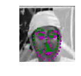

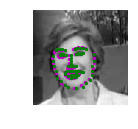

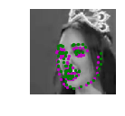

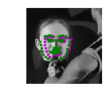

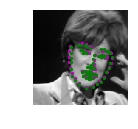

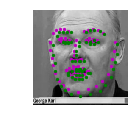

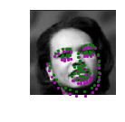

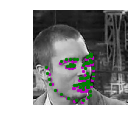

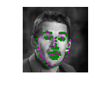

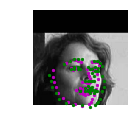

```python
## TODO: visualize your test output
# you can use the same function as before, by un-commenting the line below:

visualize_output(test_images, test_outputs, gt_pts)
```

Once you've found a good model (or two), save your model so you can load it and use it later!

Save your models but please **delete any checkpoints and saved models before you submit your project** otherwise your workspace may be too large to submit.

```python
## TODO: change the name to something uniqe for each new model
model_dir = 'saved_models/'
model_name = 'keypoints_model_1.pt'

# after training, save your model parameters in the dir 'saved_models'
torch.save(net.state_dict(), model_dir+model_name)
```

After you've trained a well-performing model, answer the following questions so that we have some insight into your training and architecture selection process. Answering all questions is required to pass this project.

### Question 1: What optimization and loss functions did you choose and why?

**Answer**: I used Adam optimizer because Adam combines the good properties of Adadelta and RMSprop and hence tend to do better for most of the problems. I used the SmoothL1Loss Loss function because it combines the advantages from mean square error and L1Loss and it gives me better results than mean square error.

### Question 2: What kind of network architecture did you start with and how did it change as you tried different architectures? Did you decide to add more convolutional layers or any layers to avoid overfitting the data?

**Answer**: my first architecture was suffering from overfitting so I reduced the size of the layers, used many dropout layers and decrease the learning rate

### Question 3: How did you decide on the number of epochs and batch_size to train your model?

**Answer**: batch_size: I had tried many values and choose 10 because it gives the best result and large values through run time error number of epochs: after setting final parameters I trained the model using 50 epochs then I selected the number with the minimum loss

## Feature Visualization

Sometimes, neural networks are thought of as a black box, given some input, they learn to produce some output. CNN's are actually learning to recognize a variety of spatial patterns and you can visualize what each convolutional layer has been trained to recognize by looking at the weights that make up each convolutional kernel and applying those one at a time to a sample image. This technique is called feature visualization and it's useful for understanding the inner workings of a CNN.

In the cell below, you can see how to extract a single filter (by index) from your first convolutional layer. The filter should appear as a grayscale grid.

```
[[-0.16378754  0.02742555 -0.05828463  0.04390394 -0.11021432]
 [-0.09384389 -0.19679205 -0.03199677 -0.20432207 -0.14175715]
 [ 0.05665844  0.08824572 -0.00406675  0.14960726  0.17753313]
 [-0.16424121 -0.00635044 -0.0491353  -0.11530216 -0.0729301 ]
 [-0.10774012 -0.07931873 -0.05379002  0.05268074 -0.19006115]]
(5, 5)
```

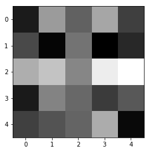

```python
# Get the weights in the first conv layer, "conv1"
# if necessary, change this to reflect the name of your first conv layer
weights1 = net.conv1.weight.data

w = weights1.numpy()

filter_index = 0

print(w[filter_index][0])
print(w[filter_index][0].shape)

# display the filter weights
plt.imshow(w[filter_index][0], cmap='gray')
```

## Feature maps

Each CNN has at least one convolutional layer that is composed of stacked filters (also known as convolutional kernels). As a CNN trains, it learns what weights to include in it's convolutional kernels and when these kernels are applied to some input image, they produce a set of **feature maps**. So, feature maps are just sets of filtered images; they are the images produced by applying a convolutional kernel to an input image. These maps show us the features that the different layers of the neural network learn to extract. For example, you might imagine a convolutional kernel that detects the vertical edges of a face or another one that detects the corners of eyes. You can see what kind of features each of these kernels detects by applying them to an image. One such example is shown below; from the way it brings out the lines in an the image, you might characterize this as an edge detection filter.

[figure not shown]

Next, choose a test image and filter it with one of the convolutional kernels in your trained CNN; look at the filtered output to get an idea what that particular kernel detects.

### TODO: Filter an image to see the effect of a convolutional kernel

```
(224, 224)
```

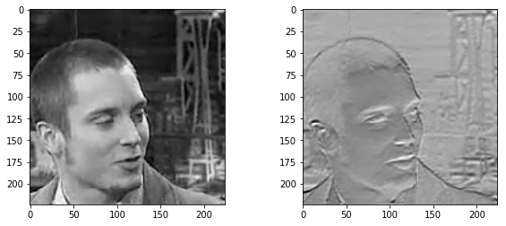

```python
import cv2
##TODO: load in and display any image from the transformed test dataset

## TODO: Using cv's filter2D function,
## apply a specific set of filter weights (like the one displayed above) to the test image
image = test_images[7].data   # get the image from it's Variable wrapper
image = image.numpy()   # convert to numpy array from a Tensor
image = np.transpose(image, (1, 2, 0))
image = np.squeeze(image)
print(image.shape)
#cv2.imshow(image,'image')
c = cv2.filter2D(image, -1, w[int((i-1)/2)][0])

fig = plt.figure(figsize=(10, 4))
fig.add_subplot(1, 2, 1)
plt.imshow(image, cmap='gray')
fig.add_subplot(1, 2, 2)
plt.imshow(c, cmap='gray')
plt.show()
```

### Question 4: Choose one filter from your trained CNN and apply it to a test image; what purpose do you think it plays? What kind of feature do you think it detects?

**Answer**: (does it detect vertical lines or does it blur out noise, etc.) detect edges as a high pass filter

## Moving on!

Now that you've defined and trained your model (and saved the best model), you are ready to move on to the last notebook, which combines a face detector with your saved model to create a facial keypoint detection system that can predict the keypoints on *any* face in an image!